# Project2

Project 2 I will analyze the titanic data set to determine which factors correlate with Survival. When I look through the data set, there are three variables that I believe could impact survival, and those are Age, Sex, and Pclass. The reason that I state this is because due to a culture of chivalry at that time, women would not be asked to sacrifice their lives, as opposed to men. I also think age could be a factor, since older people might sacrifice their lives before younger people, since they have already lived a good portion of their lives, and I don't think very young males would be expected to be chivalrous. Also, I think there could be an element where those of a higher socioeconomic status might be given more of an access to the life boats compared to those of a lower socioeconomic status, and Pclass is a proxy for that. On a side note, this is how I approach data analysis, I use my intuitions to think about what meaningful questions to ask. Then I allow the data to answer these questions. This differs from an approach taken in philosophy. For example, when dealing with the hard problem of consciousness and materialism, I would show how consciousness arising out of nonconscious matter is a form of strong emergence, and how strong emergence is reduced to a violation of ex nihilo nihil fit, and that the principle of ex nihilo nihil fit is self-evidently true independent of any data. It would be a metaphysical axiom. This is not the method that I see exists in data analysis. Your intuitions and reasoning can be a guide in allowing you to ask the best questions, but the answers come from the manipulation of data.

As far as the questions that I will ask to determine factors that correlate with survival, I will ask these questions based upon the three variables that I believe are significant.

1. How does Sex correlate with Survival?
2. How does Pclass correlate with Survival?
3. How does Age correlate with Survival?
4. How does Sex correlate with Survival based upon Age
5. How does Sex correlate with Survival based upon Pclass?

For each of these questions, I will calculate the percent that survived grouped by sex, pclass, and age alone, then I will calculate the percent that survived based upon sex and age, and then sex and pclass. From this percent chance of survival, a strong or weak correlation will be determined. I will make graphs for the analyses that include three variables, and I might go into more depth when it comes to one of the questions asked.

As far as the data wrangling is concerned, I will start with the titanic data set, and drop the Passenger, Survived, Name, SibSp, Parch, Ticket, Fare, Cabin., and Embarked columns. I will keep the Survived, Pclass, Sex, and Age column, since the goal is to see how Pclass, Sex, and Age impact Survival. When it comes to the questions of how age correlates with survival, I have decided to drop the rows that do not have an age. This should not be a problem, since 714 out of the 891 individuals have an age associated with them. This means that 177 rows will be dropped for datasets that include age as a variable. I will create columns two new columns that make age and survival more relevant to my analysis. From survival, I will create a column called percent chance of survival, which allows me to determine the percent chance of survival based upon age, sex, and pclass. I will also create an age bracket variable based upon age.

```python
# To start I will perform these steps
# 1. Import all of the necessary libraries
import numpy as np
import matplotlib as plt
import pandas as pd
import seaborn as sns
%matplotlib inline

# 2. Read in the titanic csv file
titanic = pd.read_csv("titanic-data.csv")

# 3. Select only the columns from the titanic dataset that I need for the desired analysis
project = pd.DataFrame(titanic, columns = ["Sex", "Pclass", "Age", "Survived"])

# 4. Create new columns that I think are necessary for the desired analysis
project["Sex"] = project["Sex"].astype("category")
project["Pclass"] = project["Pclass"].astype("category")
project["Survived"] = project["Survived"].astype("category")
project["Percent_Chance_of_Survival"] = project["Survived"].astype("float") * 100

# 5. Create the helper function that will create an age bracket based upon age
def convage(row):
    if row["Age"] <= 10:
        val = "1 - 10"
    elif row["Age"] <= 20:
        val = "11 - 20"
    elif row["Age"] <= 40:
        val = "21 - 40"
    elif row["Age"] <= 60:
        val = "41 - 60"
    else:
        val = "over 60"
    return val

# 6. Create another helper function that will create an age bracket based upon age
def convage1(row):
    if row["Age"] <= 15:
        val = "11 - 15"
    else:
        val = "16 - 20"
    return val
```

```python
# Find the percent chance of survival for all passengers
question_a = pd.DataFrame(project, columns = ["Percent_Chance_of_Survival"]) # Selecting appropriate columns
question_a.mean() # Calculating the percent chance of survival
```

```
Percent_Chance_of_Survival    38.383838
dtype: float64
```

38.38 percent of the people on the Titanic surivived

```python
# Find the number of males and females on the Titanic
question_b = pd.DataFrame(project, columns = ["Sex"]) # Selecting appropriate columns
question_b.groupby("Sex").size() # Counting the number of males and females on the Titanic
```

```
Sex
female    314
male      577
dtype: int64
```

There were 314 females and 577 males on the Titanic

```python
# Find the number of people from Pclass 1, 2, and 3 ont the Titanic
question_b = pd.DataFrame(project, columns = ["Pclass"]) # Selecting appropriate columns
question_b.groupby("Pclass").size() # Counting the number of people in different Pclasses
```

```
Pclass
1    216
2    184
3    491
dtype: int64
```

There were 216 people from Pclass 1, 184 people from Pclass 2, and 491 people from Pclass 3 on the Titanic

```python
# Finding the percent chance of survival based upon sex
question1 = pd.DataFrame(project, columns = ["Sex", "Percent_Chance_of_Survival"]) # Selecting appropriate columns
question1.groupby("Sex").mean() # Calculating the percent chance of survival
```

| Sex | Percent_Chance_of_Survival |
| --- | --- |
| female | 74.203822 |
| male | 18.890815 |

Given that sex is the independent variable, and percent chance of survival is dependent, the results are that 74.20 percent of females survived, and 18.89 percent of males survived.

```python
# Finding the percent chance of survival based upon Pclass, which is a proxy for social status
question2 = pd.DataFrame(project, columns = ["Pclass", "Percent_Chance_of_Survival"]) # Selecting appropriate columns
question2.groupby("Pclass").mean() # Calculating the percent chance of survival
```

| Pclass | Percent_Chance_of_Survival |
| --- | --- |
| 1 | 62.962963 |
| 2 | 47.282609 |
| 3 | 24.236253 |

Given that pclass is the independent variable, and percent chance of survival is dependent, the results are that 62.96 percent of those is pclass 1 survived, 47.28 percent of those in pclass 2 survived, and 24.24 percent of those in pclass 3 survived.

```python
# Finding the percent chance of survival based upon Age, by separating individuals into age brackets
question3 = pd.DataFrame(project, columns = ["Age", "Percent_Chance_of_Survival"]) # Selecting appropriate columns
question3 = question3.dropna() # Dropping all rows that have no value for age
question3["Age_Bracket"] = question3.apply(convage, axis = 1)  # Creating the Age Bracket column
question3 = pd.DataFrame(question3, columns = ["Age_Bracket", "Percent_Chance_of_Survival"]) # Selecting appropriate columns
question3.groupby("Age_Bracket").mean() # Calculating the percent chance of survival
```

| Age_Bracket | Percent_Chance_of_Survival |
| --- | --- |
| 1 - 10 | 59.375000 |
| 11 - 20 | 38.260870 |
| 21 - 40 | 39.740260 |
| 41 - 60 | 39.062500 |
| over 60 | 22.727273 |

Given that age bracket is the independent variable, and percent chance of survival is dependent, the results are that 59.38 percent of those between 1 - 10 survive, 38.26 percent of those between 11 - 20 survive, 39.74 percent of those between 21 - 40 survive, 39.06 percent of those between 41 - 60 survive, and 22.73 percent of those over 60 survive.

```python
# Finding out whether certain age brackets have a much better chance of survival based upon sex
question4 = pd.DataFrame(project, columns = ["Sex", "Age", "Percent_Chance_of_Survival"]) # Selecting appropriate columns
question4 = question4.dropna() # Dropping all rows that have no value for age
question4["Age_Bracket"] = question4.apply(convage, axis = 1) # Creating the Age Bracket column
question4 = pd.DataFrame(question4, columns = ["Sex", "Age_Bracket", "Percent_Chance_of_Survival"]) # Selecting appropriate columns
question4.groupby(["Sex","Age_Bracket"]).mean() # Calculating the percent chance of survival
```

| Sex | Age_Bracket | Percent_Chance_of_Survival |
| --- | --- | --- |
| female | 1 - 10 | 61.290323 |
|  | 11 - 20 | 73.913043 |
|  | 21 - 40 | 78.676471 |
|  | 41 - 60 | 75.555556 |
|  | over 60 | 100.000000 |
| male | 1 - 10 | 57.575758 |
|  | 11 - 20 | 14.492754 |
|  | 21 - 40 | 18.473896 |
|  | 41 - 60 | 19.277108 |
|  | over 60 | 10.526316 |

In this analysis, I wanted to determine the percent chance of survival based upon both sex and age bracket.

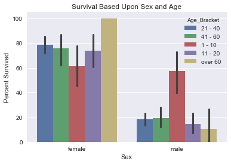

```python
# Creating a barplot of the above analysis
barplot = sns.barplot(x="Sex", y="Percent_Chance_of_Survival", hue="Age_Bracket", data = question4) # Creating barplot
barplot.set(xlabel = "Sex", ylabel = "Percent Survived", title = "Survival Based Upon Sex and Age") # Creating labels
barplot
```

Here is a barplot for the previous analysis in which sex and age bracket were the variables that survived depended upon.

```python
#  Splitting the 11 - 20 Age bracket for men into an 11 - 15 and a 16 - 20, then seeing if there is a significant difference
question4a = pd.DataFrame(project, columns = ["Sex", "Age", "Percent_Chance_of_Survival"]) # Selecting appropriate columns
question4a = question4a[question4a.Sex == "male"] # Selecting only rows where the sex is male
question4a = question4a[(question4a.Age >= 11) & (question4a.Age <= 20)] # Selecting only rows where age is between certain values
question4a["Age_Bracket"] = question4a.apply(convage1, axis = 1) # Creating the Age Bracket column
question4a = question4a.drop("Age", axis = 1) # Dropping the Age column
question4a.groupby("Age_Bracket").mean() # Calculating percent chance of survival
```

| Age_Bracket | Percent_Chance_of_Survival |
| --- | --- |
| 11 - 15 | 28.571429 |
| 16 - 20 | 12.903226 |

In this analysis, I split the 11 - 20 age bracket into 11 - 15, and 16 - 20, and then I wanted to determine their correlation with survival

```python
# Finding out the interrelation between Pclass and Sex
question5 = pd.DataFrame(project, columns = ["Sex", "Pclass", "Percent_Chance_of_Survival"]) # Selecting appropriate columns
question5.groupby(["Sex","Pclass"]).mean() # Calculating the percent chance of survival
```

| Sex | Pclass | Percent_Chance_of_Survival |
| --- | --- | --- |
| female | 1 | 96.808511 |
|  | 2 | 92.105263 |
|  | 3 | 50.000000 |
| male | 1 | 36.885246 |
|  | 2 | 15.740741 |
|  | 3 | 13.544669 |

In this analysis, I wanted to determine the percent chance of survival based upon both sex and pclass.

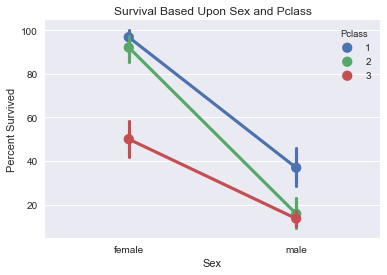

```python
# Creating a point plot based upon the above analysis
pointplot = sns.pointplot(x="Sex", y="Percent_Chance_of_Survival", hue="Pclass", data = question5) # Creating pointplot
pointplot.set(xlabel = "Sex", ylabel = "Percent Survived", title = "Survival Based Upon Sex and Pclass") # Creating labels
pointplot
```

```python
# Finding the mean age for the different Pclasses
question5a = pd.DataFrame(project, columns = ["Sex", "Pclass", "Age"]) # Selecting appropriate columns
question5a = question5a[question5a.Sex == "male"] # Selecting only rows where the sex is male
question5a = question5a.drop("Sex", axis = 1) # Dropping the sex column
question5a.groupby("Pclass").median()  # Calculating the median age for survival based upon Pclass
```

| Pclass | Age |
| --- | --- |
| 1 | 40.0 |
| 2 | 30.0 |
| 3 | 25.0 |

Conclusions

I have concluded that sex strongly correlates with survival, given that 74.20 percent of the women survived, whereas only 18.89 percent of the males survived. I have concluded that pclass strongly correlates with survival, but not to the degree that sex does, given that 62.97 percent in pclass 1 survived, 47.28 percent in pclass 2 survived, and 24.24 percent of those in pclass 3 survived. Age seemed to correlate with survival when it came to the very young and the very old, 59.38 percent of those between 1 – 10 survived, 38.26 percent of those between 11 -20 survived, 39.74 percent of those between 21 – 40 survived, 39.06 percent of those between 41 – 60 survived, and 22.73 percent of those over 60 survived. My next question was whether age is a factor in determining correlations between survival and sex. When I performed that analysis, I found that all of the age brackets, except the bracket between ages 1 – 10 had a huge difference of percent chance of survival based upon sex. It seems that my intuition about young males not expecting to be chivalrous could be correct. I then split the 11 – 20 bracket into 11 – 15, and 16 – 20, and found a significant difference between the two. It seems that the age, where male survival is affected would be somewhere between 11 – 15. My next question was about whether pclass is a factor in determining correlations between survival and sex. The interesting thing there is females in pclass 1 and pclass 2 have a percent chance of survival above 90 percent, whereas females in pclass 3 only have a 50 percent chance of survival, there was no pclass for males that was above 50 percent. If I had to break this down into a bunch of conditionals this is how it would work

The first step is to break things down by sex, if you are a female, then your chance of survival is good, whereas if you are a male, your chance of survival is bad. The two exceptions that I would provide is if you are a female in pclass 3, then your chance of survival is 50/50, and if you are a male that is between 1 – 10, your chance of survival is above 50 percent, which is much better than all of the other age groups for the males. I could break it down even further, but I think this captures a process of good decision making based upon who will survive, as opposed to who will not survive.

As far as the data set is concerned it was collected from the British Board of Trade in their investigation of the sinking. I also found that there is disagreement when it comes to primary sources about the exact number of people on board, rescued, or lost. Given that this is the case, people might have filled it what they considered missing data with their expectations. This is an issue, since any analysis is only as good as the data that it depends upon.

As far as my personal speculations are concerned, I believe that the reason women survived more than men had to do with a concept of chivalry that existed back then, a man who did not give up his life boat seat for a woman could have been considered a coward. I believe age was a factor when it came to very young males, there was no expectation for young males to be chivalrous, plus I could not see a mother going on a lifeboat, while her young son around the age of five would die. As far as survival based upon pclass, I think this probably had to do with a type of classism that existed back then. These are my speculations, but I think they are accurate.